# Estimating associations between childhood exposure to non-persistent endocrine disruptors, corticosteroids, and neurodevelopment: A study based on the parametric g-formula

Lorenzo Fabbri

## Recap

- We want to estimate the following *effects* (in children from HELIX):
  - Non-persistent EDCs and neurodevelopment (using attention as *proxy*).
  - Non-persistent EDCs and corticosteroids.
  - Corticosteroids and neurodevelopment.
- For attention we used the HIT-RT SE from the Attention Network Test.
- We did not consider individual metabolites but sums and ratios.
- We want to do so using the parametric g-formula and average contrasts.

## The pipeline

1. Estimation of balancing weights: `exposure ~ covariates`.
2. G-computation:
   1. Fit a **weighted outcome model**: `outcome ~ exposure + covariates`.
   2. Create two copies of the original dataset, with the exposure **shifted**.
   3. Predict the outcomes in the two **counterfactual** datasets.
   4. Estimate the **estimand** $\phi^\Delta = \mathbb{E} [Y^{d_1}] - \mathbb{E} [Y^{d_2}]$.

In this case:

- Cohort-specific shifting of the exposure. $d_1$ is a deterministic function setting the exposure to its 90th percentile, $d_2$ to its 10th percentile.

We also looked into **effect-modification** by sex (weights estimated separately, interaction in outcome model, estimation of marginal effects taking this into account).

## Difficulties

It looks simple, but lots of literature searches:

- DAGs for three different research questions.
- New data (corticosteroids), and still awaiting answers, and ratios difficult to interpret.
- Estimation of balancing weights for **ratios** is (apparently) still an open question.
- Usage of more **flexible modeling** approaches to estimate the ADRF (natural cubic splines).
- Careful modeling of **ratios**; it’s not that simple:
  - `log (num / den) ~ exposure + log den + covariates`.
  - `outcome ~ log (num / den)`.
- Creatinine coming from different sources.
- Proper modeling of creatinine to take into account dilution effects.
- Careful consideration of positivity violations when shifting the exposures (cohort-specific and smaller percentiles).
- Computation of **robust** standard errors for inference using `cohort` as clusters.
- Careful usage of tools to improve **replicability** across the entire project (from data loading to paper writing).

## Even more difficulties

Most likely there is reverse causality (assumption of time-ordering from DAGs is not satisfied).

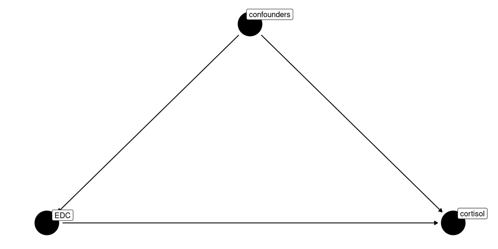

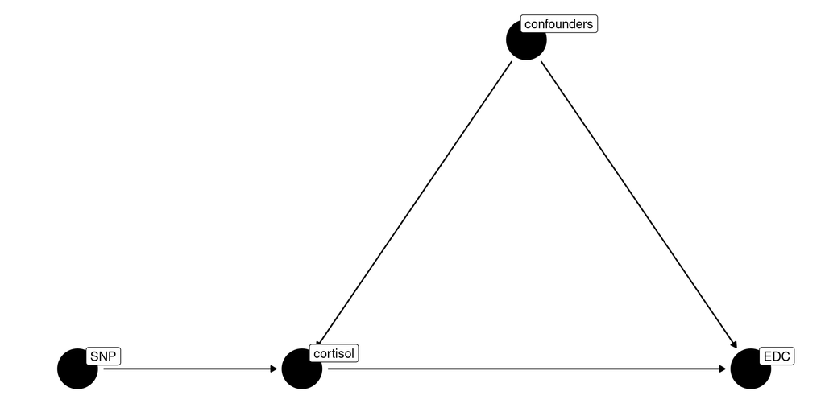

- We cannot use 2-sample MR since there are no SNPs for the *outcome*.
- We do not have single metabolites but sums and ratios.
- I am not sure it makes sense…